# Resultados del proyecto

Josué Sagastume, Cristopher Barrios, Diego Ruiz

23/5/2021

## Resultados del proyecto

### 1. Elección de variable respuesta

Para poder llegar más a fondo sobre las causas de divorcio en Guatemala y en qué departamentos tiene una cantidad más alta de divorcios, se decidió utilizar machine learning para poder predecir si dadas ciertas características la demanda será alta, media o baja.

Para poder estudiar categóricamente, se agregará una variable adicional clasificativa en el dataset para llevar a cabo la predicción. En este caso, se separó en 3 grupos.

### 2. Conjuntos de entrenamiento y prueba

Para este caso, se utilizó del conjunto total de datos, el 70% para entrenamiento y 30% para pruebas, de este modo los datos estarán equilibrados para poder realizar buenas predicciones.

### 3. Algoritmos utilizados

Para poder llegar a la solución de este problema, se aplicarán 3 algoritmos. El primero es de clustering con k-means, este para poder encontrar la cantidad óptima de grupos a utilizar para la variable respuesta categórica. El segundo algoritmo a utilizar es el de Naive Bayes, pues es un algoritmo de clasificación. Este nos brinda la ventaja de que, por su estructura, es muy asertivo, es rápido y también escalable. También se utilizó el algoritmo de Árboles de decisión, pues también clasifican la información de manera que, como resultado, se genere un modelo de en forma de árbol. La ventaja de este algoritmo, es que también puede ser utilizado para predecir datos, ayudándonos a resolver el problema en cuestión.

#### Grafica de codos de divorcios por departamento por mes

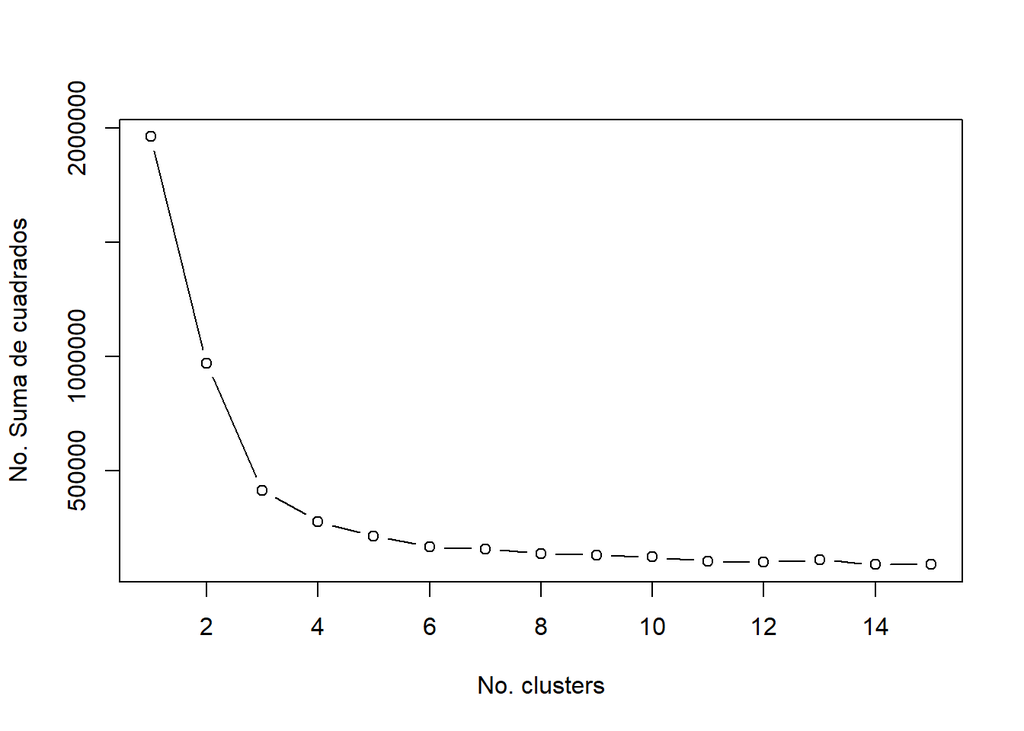

#### Numero de Clusters (Divorcios por departamento por mes)

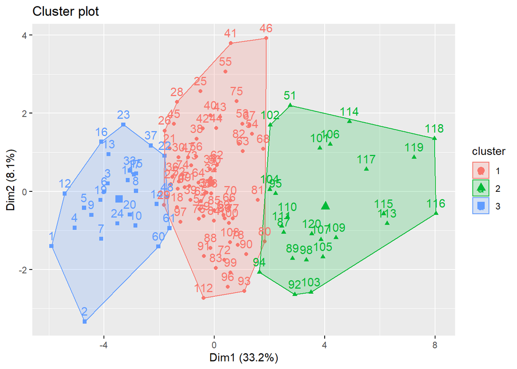

#### Aplicacion de clusters a Data Inicial y Separacion de grupos

```
## [1] 0.9084822
```

#### Aplicacion de Naive Bayes (Divorcios por departamento por mes)

```
## Confusion Matrix and Statistics
##
##                Reference
## Prediction      Demanda alta Demanda baja Demanda media
##   Demanda alta             7            0             0
##   Demanda baja             2           16             4
##   Demanda media            0            0             7
##
## Overall Statistics
##
##                Accuracy : 0.8333
##                  95% CI : (0.6719, 0.9363)
##     No Information Rate : 0.4444
##     P-Value [Acc > NIR] : 1.832e-06
##
##                   Kappa : 0.7313
##
##  Mcnemar's Test P-Value : NA
##
## Statistics by Class:
##
##                      Class: Demanda alta Class: Demanda baja
## Sensitivity                       0.7778              1.0000
## Specificity                       1.0000              0.7000
## Pos Pred Value                    1.0000              0.7273
## Neg Pred Value                    0.9310              1.0000
## Prevalence                        0.2500              0.4444
## Detection Rate                    0.1944              0.4444
## Detection Prevalence              0.1944              0.6111
## Balanced Accuracy                 0.8889              0.8500
##                      Class: Demanda media
## Sensitivity                        0.6364
## Specificity                        1.0000
## Pos Pred Value                     1.0000
## Neg Pred Value                     0.8621
## Prevalence                         0.3056
## Detection Rate                     0.1944
## Detection Prevalence               0.1944
## Balanced Accuracy                  0.8182
```

#### Aplicacion de Arboles de Decision (Divorcios por departamento por mes)

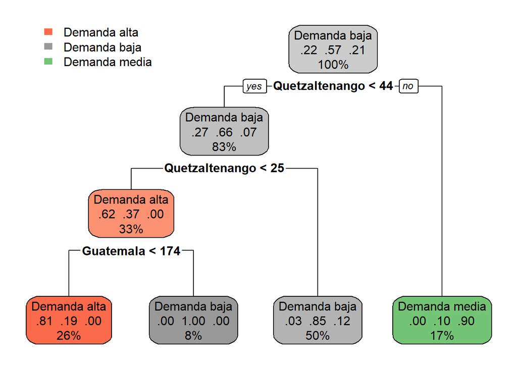

```
##               7               9              11              16              18
##  "Demanda alta"  "Demanda alta"  "Demanda alta"  "Demanda alta"  "Demanda alta"
##              22              24              26              29              33
##  "Demanda alta"  "Demanda alta"  "Demanda baja"  "Demanda alta"  "Demanda alta"
##              35              38              43              47              48
##  "Demanda baja"  "Demanda baja"  "Demanda baja"  "Demanda baja"  "Demanda alta"
##              50              52              55              57              59
##  "Demanda baja"  "Demanda baja"  "Demanda baja"  "Demanda baja"  "Demanda baja"
##              67              68              69              70              72
##  "Demanda baja"  "Demanda baja"  "Demanda baja"  "Demanda baja"  "Demanda baja"
##              73              76              81              84              86
##  "Demanda baja"  "Demanda baja"  "Demanda baja"  "Demanda baja"  "Demanda baja"
##              92              93              96             107             110
##  "Demanda baja"  "Demanda baja"  "Demanda baja" "Demanda media" "Demanda media"
##             113
## "Demanda media"
```

```
## Confusion Matrix and Statistics
##
##                Reference
## Prediction      Demanda alta Demanda baja Demanda media
##   Demanda alta             8            2             0
##   Demanda baja             0           22             1
##   Demanda media            0            0             3
##
## Overall Statistics
##
##                Accuracy : 0.9167
##                  95% CI : (0.7753, 0.9825)
##     No Information Rate : 0.6667
##     P-Value [Acc > NIR] : 0.0004894
##
##                   Kappa : 0.8344
##
##  Mcnemar's Test P-Value : NA
##
## Statistics by Class:
##
##                      Class: Demanda alta Class: Demanda baja
## Sensitivity                       1.0000              0.9167
## Specificity                       0.9286              0.9167
## Pos Pred Value                    0.8000              0.9565
## Neg Pred Value                    1.0000              0.8462
## Prevalence                        0.2222              0.6667
## Detection Rate                    0.2222              0.6111
## Detection Prevalence              0.2778              0.6389
## Balanced Accuracy                 0.9643              0.9167
##                      Class: Demanda media
## Sensitivity                       0.75000
## Specificity                       1.00000
## Pos Pred Value                    1.00000
## Neg Pred Value                    0.96970
## Prevalence                        0.11111
## Detection Rate                    0.08333
## Detection Prevalence              0.08333
## Balanced Accuracy                 0.87500
```

```
## Confusion Matrix and Statistics
##
##                Reference
## Prediction      Demanda alta Demanda baja Demanda media
##   Demanda alta             5            1             0
##   Demanda baja             3           23             1
##   Demanda media            0            0             3
##
## Overall Statistics
##
##                Accuracy : 0.8611
##                  95% CI : (0.705, 0.9533)
##     No Information Rate : 0.6667
##     P-Value [Acc > NIR] : 0.007569
##
##                   Kappa : 0.6939
##
##  Mcnemar's Test P-Value : NA
##
## Statistics by Class:
##
##                      Class: Demanda alta Class: Demanda baja
## Sensitivity                       0.6250              0.9583
## Specificity                       0.9643              0.6667
## Pos Pred Value                    0.8333              0.8519
## Neg Pred Value                    0.9000              0.8889
## Prevalence                        0.2222              0.6667
## Detection Rate                    0.1389              0.6389
## Detection Prevalence              0.1667              0.7500
## Balanced Accuracy                 0.7946              0.8125
##                      Class: Demanda media
## Sensitivity                       0.75000
## Specificity                       1.00000
## Pos Pred Value                    1.00000
## Neg Pred Value                    0.96970
## Prevalence                        0.11111
## Detection Rate                    0.08333
## Detection Prevalence              0.08333
## Balanced Accuracy                 0.87500
```